# Sales Forecasting

Tommy Brant

## Executive Summary

We will use a dataset of software sales to forecast montly and annual sales. . .

Libraries

```r
#load libraries
library(stringr)
library(stringr)
library(plyr)
library(ggplot2)
library(dplyr)
library(lubridate)
library(zoo)
library(tseries)
library(forecast)
library(base)
```

See appendix for description of sales data

Reading the Data

```r
#-----file of cat's of item_id's
item_cats_file<-'../Data/item_categories.csv'

#----file relating items
items_file<-'../Data/items.csv'


train_file<-'../Data/sales_train_v2.csv'
test_file<-'../Data/test.csv'

#----don't read stringasfactors bc only string is date. cant always do this bc of high feature possibility
#if (!exists('sales_raw_df')) sales_raw_df<-read.csv(train_file, header=T, stringsAsFactors=FALSE)

#---doin lazy-like
if (!exists('sales_raw_df')) sales_raw_df<-read.csv(train_file, header=T)
if (!exists('item_cats_df')) item_cats_df<-read.csv(item_cats_file, header=T, encoding="UTF-8") #not going to use this often
if (!exists('items_df')) items_df<-read.csv(items_file, header=T, encoding="UTF-8")

#---add item_cat_id to base data
if (!exists('sales_df')) sales_df<-merge(sales_raw_df,items_df[,-1], by="item_id")

#---tester df (expendable)
#if (!exists('sales_df1')) sales_df1<-read.csv(train_file, header=T)


# --- clear memory
#rm(list = c('test', 'sales_raw_df', 'sales_raw_df1', 'sales_df', 'sales_by_item_id', 'max_index', 'item_cats_df', 'items_df', 'future', 'future1'))
```

Scan the Data

```r
str(sales_df)
```

```
## 'data.frame':    2935849 obs. of  7 variables:
##  $ item_id         : int  0 1 1 1 1 1 1 2 2 3 ...
##  $ date            : Factor w/ 1034 levels "01.01.2013","01.01.2014",..: 26 366 675 113 45 190 125 805 406 156 ...
##  $ date_block_num  : int  20 20 21 15 15 18 19 19 22 18 ...
##  $ shop_id         : int  54 55 55 55 55 55 55 54 54 54 ...
##  $ item_price      : num  58 4490 4490 4490 4490 4490 4490 58 58 100 ...
##  $ item_cnt_day    : num  1 1 1 1 1 1 1 1 1 1 ...
##  $ item_category_id: int  40 76 76 76 76 76 76 40 40 40 ...
```

Sampling the sample

```r
head(sales_df)
```

```
##   item_id       date date_block_num shop_id item_price item_cnt_day
## 1       0 01.09.2014             20      54         58            1
## 2       1 11.09.2014             20      55       4490            1
## 3       1 20.10.2014             21      55       4490            1
## 4       1 04.04.2014             15      55       4490            1
## 5       1 02.04.2014             15      55       4490            1
## 6       1 06.07.2014             18      55       4490            1
##   item_category_id
## 1               40
## 2               76
## 3               76
## 4               76
## 5               76
## 6               76
```

```r
tail(sales_df)
```

```
##         item_id       date date_block_num shop_id item_price item_cnt_day
## 2935844   22168 02.02.2013              1      42      799.0            1
## 2935845   22168 08.03.2013              2      43      798.5            1
## 2935846   22168 13.09.2013              8      12      799.0            1
## 2935847   22168 20.01.2013              0       2      799.0            1
## 2935848   22168 17.02.2013              1      16      799.0            1
## 2935849   22169 21.03.2014             14      25     4349.0            1
##         item_category_id
## 2935844               62
## 2935845               62
## 2935846               62
## 2935847               62
## 2935848               62
## 2935849               69
```

```r
names(sales_df) #appears to be daily sales/transactions per location per item sold
```

```
## [1] "item_id"          "date"             "date_block_num"
## [4] "shop_id"          "item_price"       "item_cnt_day"
## [7] "item_category_id"
```

```r
nrow(sales_df) #2,935,849 sales over x years
```

```
## [1] 2935849
```

```r
length(unique(sales_df$item_id)) #21807 unique items to sell
```

```
## [1] 21807
```

This is not a real data set b/c there are no NA’s or invalid entries.

```r
#-----lazy inefficient way to scan for NAs but great for 'small' data sets
table(is.na(sales_df)) #no NA's
```

```
##
##    FALSE
## 20550943
```

Preprocesssing

```r
#---Date/Time
#---Big thanks to lubridate for making this ez

if (class(sales_df$date)!='Date') sales_df$date<-dmy(sales_df$date) #DON'T RUN THIS A SECOND TIME

#-----create years for annual analysis
sales_df<-sales_df %>%
  mutate(year = year(sales_df$date)) %>%
  mutate(month = month(sales_df$date))

#---------SORTING BY DATE
#sales_df %>%
#  arrange(sales_df$date)



#----Item_id as factor
sales_df$item_id<-as.factor(sales_df$item_id)


#---Shop_id as factor
sales_df$shop_id<-as.factor(sales_df$shop_id)
```

Exploratory Questions

1. “What item has the most lifetime sales dollar”
2. “What shop has the best sales in 2014”
3. “what has the most consecutive sales?”
4. “What seasonal patterns are noticeable?”
5. ‘what category of items sold the best?’

6 ‘What is daily sales activity?’

7. ‘Monthly sales activity?’

Exploring

1. Top Performing Lifetime sales by Item_id

```r
#----from definittions, date_block_num represents a consecutive month number, used for convenience. January 2013 is 0, February 2013 is 1,..., October 2015 is 33


#-----show top performing lifetime sales by item_id

sales_by_item_id<-sales_df %>%
  #select(date, date_block_num, shop_id, item_id, item_price, item_cnt_day) %>% #-----in a real world exapmle, we'd leverage this part
  #na.omit() %>%  #---------would be used in real world data
  group_by(item_id) %>%
  summarise(
    totals_sales = sum(item_price),
    avg_sales = mean(item_price),
    count = length(item_price)
  ) %>%
  arrange(desc(totals_sales)) #%>%
```

2. Monthly performance

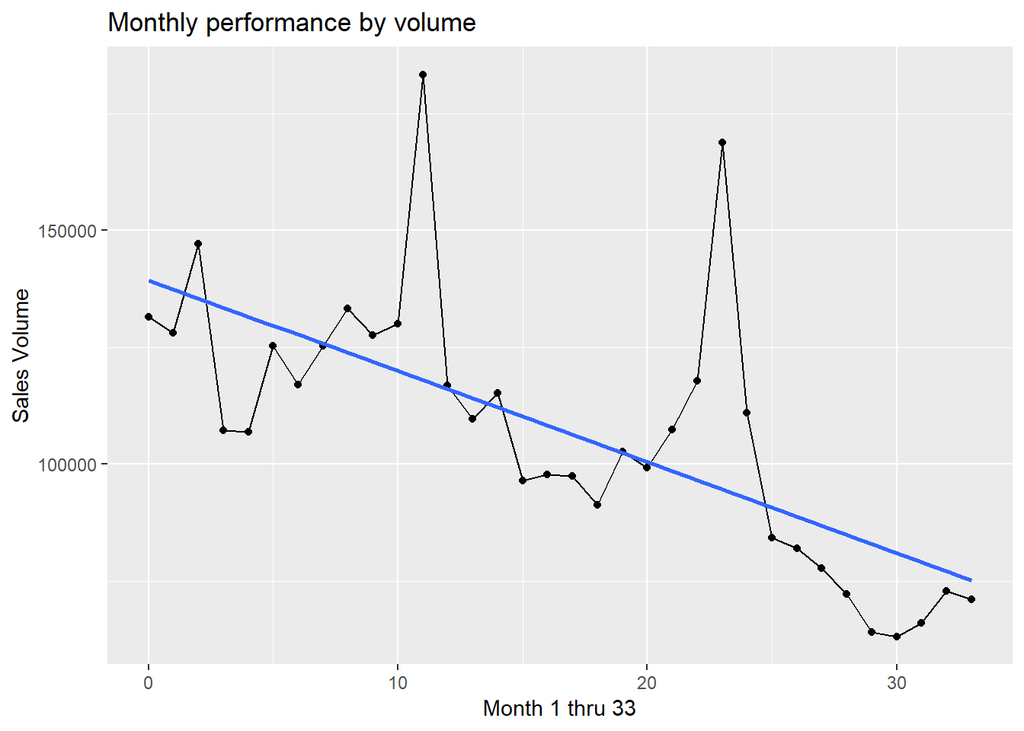

```r
#---total sales by volume monthly


sales_df %>%
group_by(date_block_num) %>%
  summarise(
    totals_sales = sum(item_cnt_day)
    #, avg_sales = mean(item_cnt_day)
    #, count = length(item_price)
  ) %>%
  #arrange(desc(totals_sales))

  ggplot(aes(x=date_block_num, y=totals_sales)) +
    geom_line() +
    geom_point() +
    #geom_line(aes(y=avg_sales), color="red") +
    geom_smooth(method = "lm", se = FALSE) +
    labs(title="Monthly performance by volume") +
    xlab("Month 1 thru 33") +
    ylab("Sales Volume")
```

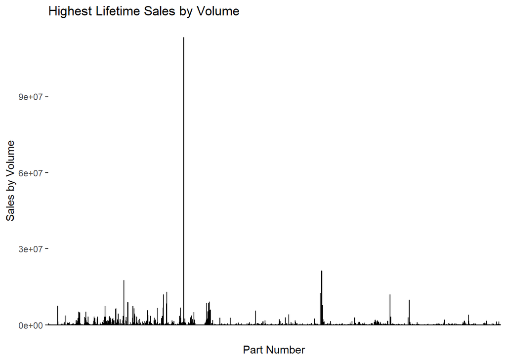

```r
#max(sales_by_item_id$totals_sales) #113,264,259


max_index<-sales_by_item_id %>%
  filter(totals_sales == max(sales_by_item_id$totals_sales))


#-----note there are some high dollars items, and even some low dollar high volume sales. good mix

ggplot(sales_by_item_id, aes(x=item_id,y=totals_sales))+
    geom_bar(stat="identity", width=1, fill="gray72",color="black")+ # fill="steelblue2")+
    ylab("Sales by Volume")+
    xlab("Part Number")+
    ggtitle("Highest Lifetime Sales by Volume") +
    theme(axis.text.x=element_blank(),
              axis.ticks.x=element_blank())
```

The most sales of any item in the portfolio was 113264258.952122 with item id 6675

Better viewing of top performers

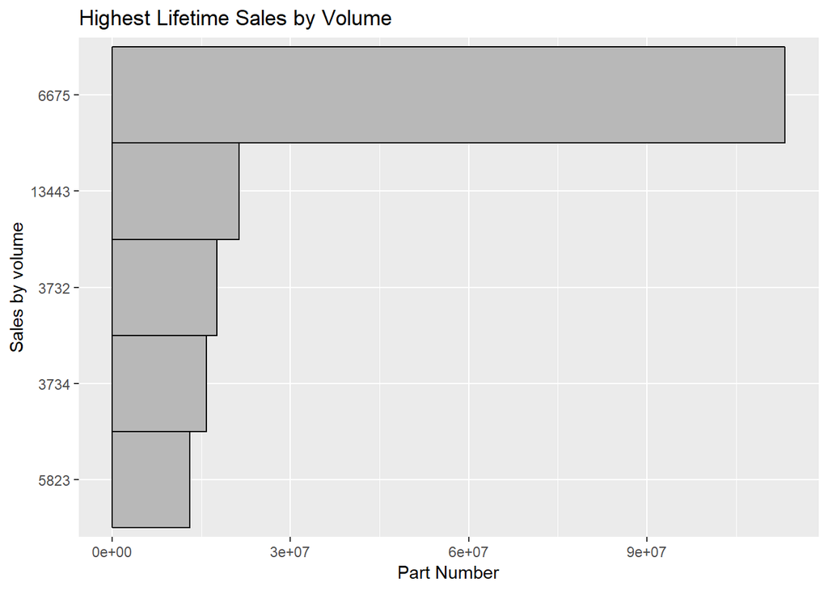

```r
#-----make sortable by category
sales_by_item_id$item_id<-factor(sales_by_item_id$item_id, levels=sales_by_item_id$item_id[order(sales_by_item_id$totals_sales)])


  ggplot(sales_by_item_id[1:5,], aes(x=item_id,y=totals_sales))+  #filter freq >1
    geom_bar(stat="identity", width=1, fill="gray72",color="black")+ # fill="steelblue2")+
    coord_flip()+
    xlab("Sales by volume")+
    ylab("Part Number")+
    ggtitle("Highest Lifetime Sales by Volume")
```

```r
    #theme(axis.text.x=element_blank(),
    #          axis.ticks.x=element_blank())
```

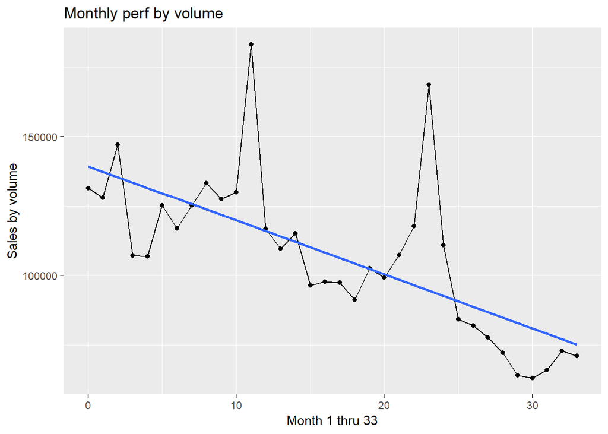

```r
#---TIME SERIES VIEW OF DATA
#---MONTHLY ITEMS SOLD PER MONTH FOR 33 MONTHS

sales_df %>%
group_by(date_block_num) %>%
  summarise(
    totals_sales = sum(item_cnt_day)
    #, avg_sales = mean(item_cnt_day)
    #, count = length(item_price)
  ) %>%
  #arrange(desc(totals_sales))

  ggplot(aes(x=date_block_num, y=totals_sales)) +
    geom_line() +
    geom_point() +
    #geom_line(aes(y=avg_sales), color="red") +
    geom_smooth(method = "lm", se = FALSE) +
    labs(title = "Monthly perf by volume") +
    ylab("Sales by volume")+
    xlab("Month 1 thru 33")
```

Daily #’s

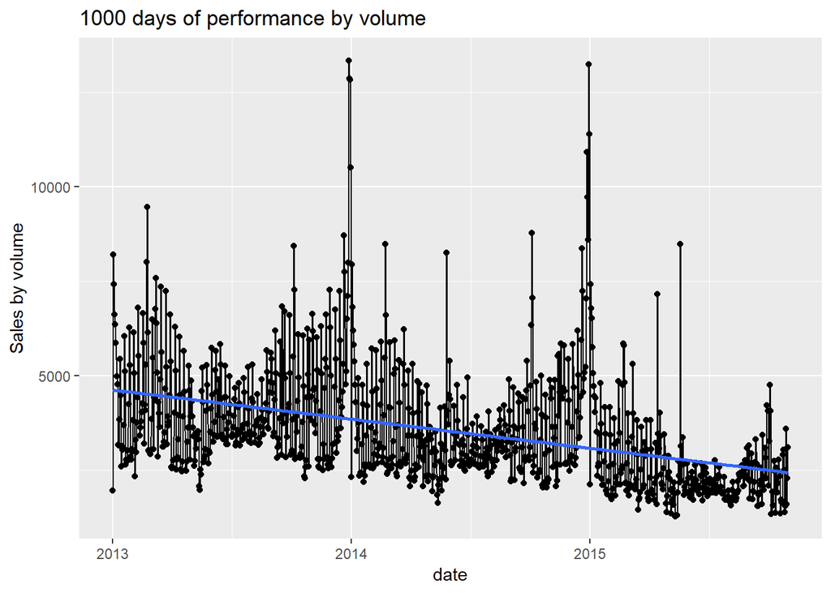

```r
sales_df %>%
  group_by(date) %>%
  summarise(
    totals_sales = sum(item_cnt_day)
    , total_dollars = sum(item_price)
  ) %>%

  ggplot(aes(x=date, y=totals_sales)) +
    geom_line() +
    geom_point() +
    geom_smooth(method = "lm", se = FALSE) +
    labs(title= "1000 days of performance by volume") +
    ylab("Sales by volume")
```

Year over Year views - $’s and volume

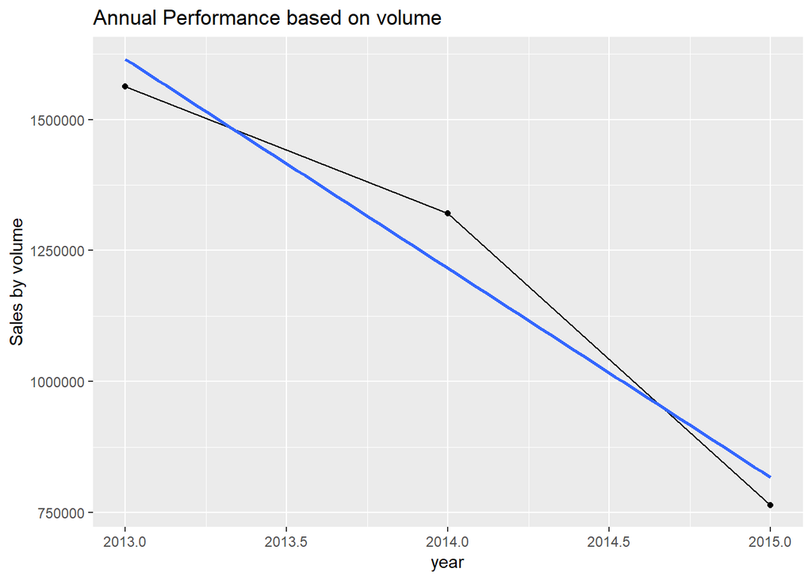

```r
sales_df %>%
  group_by(year) %>%
  summarise(
    totals_sales = sum(item_cnt_day)
    , total_dollars = sum(item_price)
  ) %>%

  ggplot(aes(x=year, y=totals_sales)) +
    geom_line() +
    geom_point() +
    geom_smooth(method = "lm", se = FALSE) +
    labs(title = "Annual Performance based on volume") +
    ylab("Sales by volume")
```

Rolling Mean

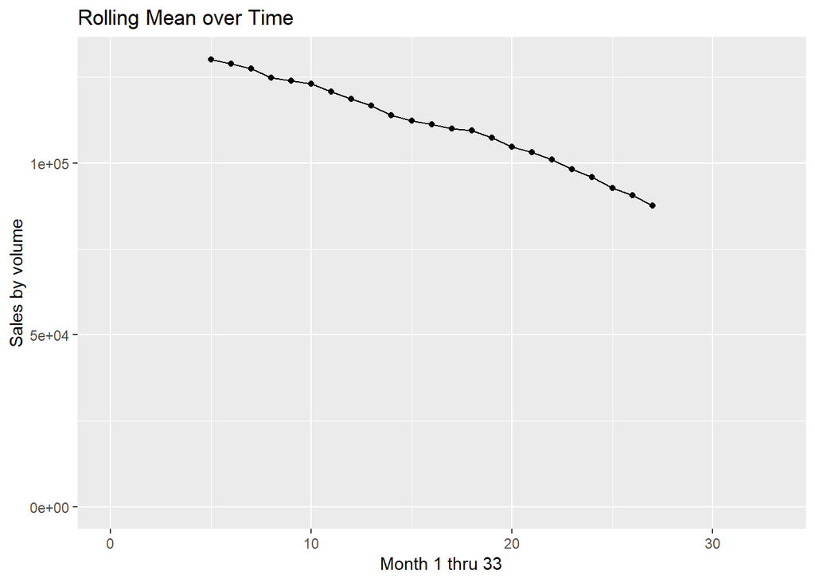

```r
#names(sales_df)
sales_df %>%
  group_by(date_block_num) %>%
  summarise(
    totals_sales = sum(item_cnt_day)
    , total_dollars = sum(item_price)
  ) %>%
  mutate(roll_mean = rollmean(totals_sales, 12, fill=NA)) %>%


ggplot(aes(x=date_block_num, y=roll_mean)) +
    geom_line() +
    geom_point() +
    scale_y_continuous(limits = c(0, NA)) +
    labs(title = "Rolling Mean over Time") +
    ylab("Sales by volume")+
    xlab("Month 1 thru 33")
```

Time Series Analysis - Composition Breakdown

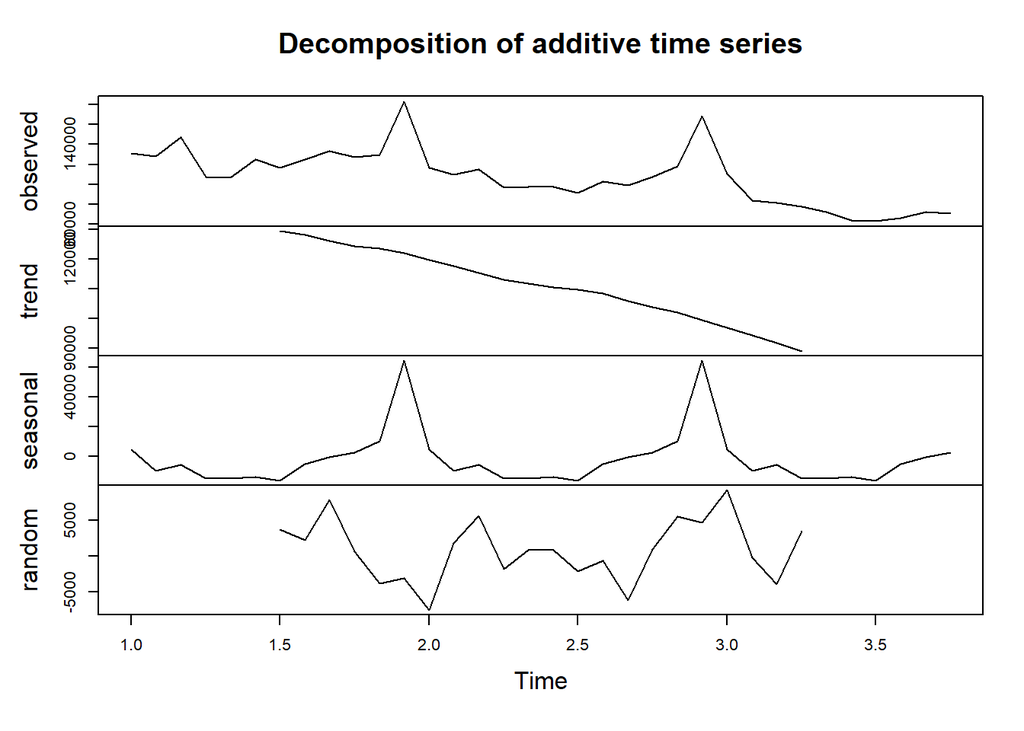

```r
#---try decompose() and forecast()
decomp_sales_df <- sales_df %>%
  group_by(date_block_num) %>%
  summarise(
    totals_sales = sum(item_cnt_day)
  )

  decompose_sales<-decompose(ts(decomp_sales_df$totals_sales,freq=12), "additive")

  #plot(as.ts(decompose_sales$seasonal))
  #plot(as.ts(decompose_sales$trend))
  #plot(as.ts(decompose_sales$random))
  plot(decompose_sales)
```

ARIMA PREDICTIONS

```r
#Univariate variable data
obs_data<-ts(decomp_sales_df$totals_sales,freq=12)

#Explore ARIMA model - parameters = 0,1,0
future<-forecast(auto.arima(obs_data))
```

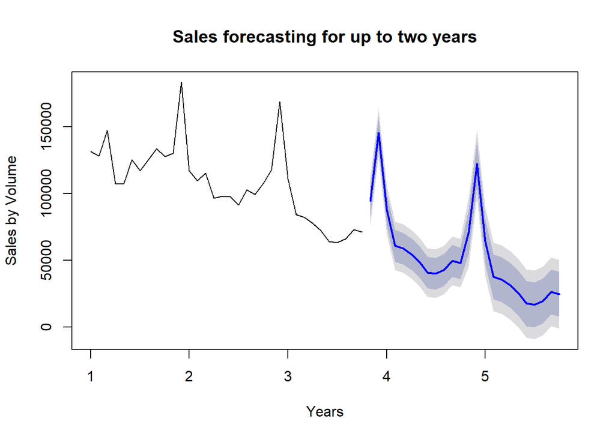

```r
#visualize
plot(future, ylab = 'Sales by Volume' ,xlab = 'Years', main="Sales forecasting for up to two years")
```

END

File descriptions and Definitions

sales_train.csv - the training set. Daily historical data from January 2013 to October 2015.

test.csv - the test set. You need to forecast the sales for these shops and products for November 2015.

sample_submission.csv - a sample submission file in the correct format.

items.csv - supplemental information about the items/products.

item_categories.csv - supplemental information about the items categories.

shops.csv- supplemental information about the shops.

Data fields

ID - an Id that represents a (Shop, Item) tuple within the test set

shop_id - unique identifier of a shop

item_id - unique identifier of a product

item_category_id - unique identifier of item category

item_cnt_day - number of products sold. You are predicting a monthly amount of this measure

item_price - current price of an item

date - date in format dd/mm/yyyy

date_block_num - a consecutive month number, used for convenience. January 2013 is 0, February 2013 is 1,…, October 2015 is 33

item_name - name of item

shop_name - name of shop

item_category_name - name of item category

Real END